# Graphing a Handful of Vanguard Funds

Author

Rick Dean

Abstract

Taking a handful of Vanguard mutual index funds, perform data wrangling and graphing of adjusted closing prices using the R language.

```r
library(data.table)
library(ggplot2)
library(quantmod)
library(magrittr)
library(purrr)
library(RplotterPkg)
library(RstocksPkg)
```

# 1 Graphing a Handful of Vanguard Funds

## 1.1 Vanguard Index Fund Closing Prices

Select the Vanguard index funds.

The following funds are selected for graphing.

- Bonds:
  - [VBILX](https://investor.vanguard.com/investment-products/mutual-funds/profile/vbilx) – Inter-Term Bond Index Fund Admiral Shares
  - [VBIRX](https://investor.vanguard.com/investment-products/mutual-funds/profile/vbirx) – Vanguard Short-Term Bond Index Fund Admiral Shares
- Growth:
  - [VIMAX](https://investor.vanguard.com/investment-products/mutual-funds/profile/vimax) – Vanguard Mid-Cap Index Fund Admiral Shares
  - [VFIAX](https://investor.vanguard.com/investment-products/mutual-funds/profile/vfiax) – Vanguard 500 Index Fund Admiral Shares
  - [VIGAX](https://investor.vanguard.com/investment-products/mutual-funds/profile/vigax) – Vanguard Growth Index Fund Admiral Shares
  - [VTSAX](https://investor.vanguard.com/investment-products/mutual-funds/profile/vtsax) – Vanguard Total Stock Market Index Fund Admiral Shares
- Balanced-Income-Value:
  - [VWELX](https://investor.vanguard.com/investment-products/mutual-funds/profile/vwelx) – Vanguard Wellington Fund Investor Shares
  - [VWINX](https://investor.vanguard.com/investment-products/mutual-funds/profile/vwinx) – Vanguard Wellesley Income Fund Investor Shares
  - [VVIAX](https://investor.vanguard.com/investment-products/mutual-funds/profile/vviax) – Vanguard Value Index Fund Admiral Shares
- Sector-Foreign:
  - [VGSLX](https://investor.vanguard.com/investment-products/mutual-funds/profile/vgslx) – Vanguard Real Estate Index Fund Admiral Shares
  - [VGHCX](https://investor.vanguard.com/investment-products/mutual-funds/profile/vghcx) – Vanguard Health Care Fund Investor Shares
  - [VFWAX](https://investor.vanguard.com/investment-products/mutual-funds/profile/vfwax) – Vanguard FTSE All-World ex-US Index Fund Admiral Shares

Show the fund symbols and define start/end times of interest.

Create named vectors of fund symbols and start/end times:

```r
symbols_v <- c(
  VBILX = "Inter-term Bond Index Adm-R",
  VIMAX = "Mid-Cap Index Fund Adm-R",
  VFIAX = "500 Index Fund Adm-R",
  VIGAX = "Growth Index Fund Adm-R",
  VTSAX = "Total Stock Market Index Adm-R",
  VVIAX = "Value Index Fund Adm-R",
  VGSLX = "Real Estate Index Fund-RN",
  VWELX = "Wellington Fund Inv",
  VFWAX = "FTSE All World ex-US Adm",
  VGHCX = "Health Care Fund Inv",
  VBIRX = "Short-Term Bond Index Adm-N",
  VWINX = "Wellesley Income Fund Inv-RN"
)

times_v <- c(
  start = "2019-01-01",
  end = "2022-12-31"
)
```

Get the historic closing prices for all the funds.

```r
fund_prices_dt <- RstocksPkg::get_stock_prices(
  symbols = names(symbols_v),
  from = times_v[["start"]],
  to = times_v[["end"]],
  periodicity = "weekly",
  warnings = FALSE
)
```

## 1.2 Growth Plots

Define the `data.table` for growth funds.

```r
growth_symbols_v <- c(
  VIMAX = "Mid-Cap Index Fund Adm-R",
  VFIAX = "500 Index Fund Adm-R",
  VIGAX = "Growth Index Fund Adm-R",
  VTSAX = "Total Stock Market Index Adm-R"
)
growth_dt <- fund_prices_dt[Symbol %in% names(growth_symbols_v),]
```

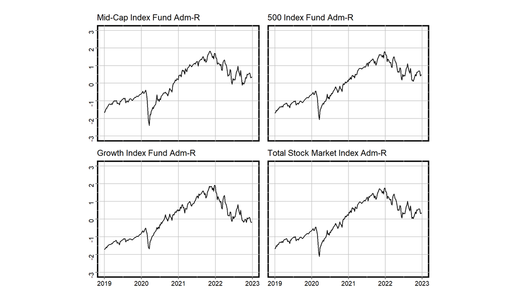

Standardized adjusted closing prices for Vanguard Growth Index Funds

```r
build_plot <- function(id, dt, symbols, show_x, show_y){
  symbol <- names(symbols)[[id]]
  plot_dt <- dt[Symbol == symbol, ]
  a_mean <- mean(plot_dt$Adjusted)
  a_sd <- sd(plot_dt$Adjusted)
  plot_dt[, Z := (Adjusted-a_mean)/a_sd]

  hide_x_tics <- TRUE
  hide_y_tics <- TRUE
  if(id %in% show_x){
    hide_x_tics <- FALSE
  }
  if(id %in% show_y){
    hide_y_tics <- FALSE
  }

  RplotterPkg::create_scatter_plot(
    df = plot_dt,
    aes_x = "Date",
    aes_y = "Z",
    subtitle = symbols[[id]],
    y_limits = c(-3, 3),
    y_major_breaks = seq(-3, 3, 1.0),
    hide_x_tics = hide_x_tics,
    hide_y_tics = hide_y_tics,
    connect = TRUE,
    show_minor_grids = FALSE,
    show_pts = FALSE
  )
}

growth_plots_lst <- purrr::map(
  1:4,
  build_plot,
  dt = growth_dt,
  symbols = growth_symbols_v,
  show_x = c(3, 4),
  show_y = c(1, 3)
)

layout <- list(
  plots = growth_plots_lst,
  rows = c(1, 1, 2, 2),
  cols = c(1, 2, 1, 2)
)

RplotterPkg::multi_panel_grid(
  layout = layout,
  row_heights = c(8, 8.5),
  col_widths = c(10.5,10)
)
```

## 1.3 Balanced-Income-Value Plots

```r
balanced_symbols_v <- c(
  VWELX = "Wellington Fund Inv",
  VWINX = "Wellesley Income Fund Inv-RN",
  VVIAX = "Value Index Fund Adm-R"
)
balanced_dt <- fund_prices_dt[Symbol %in% names(balanced_symbols_v),]
```

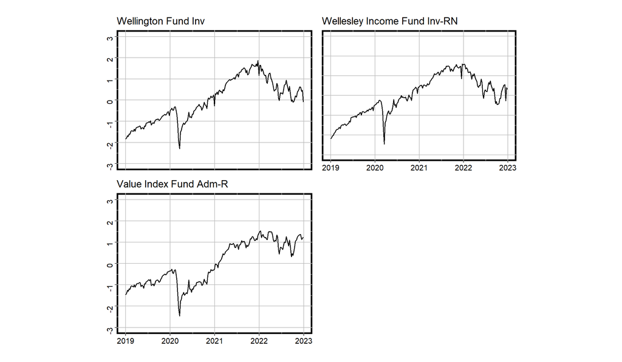

Standardized adjusted closing prices for Vanguard Balanced/Income/Value Index Funds

```r
balanced_plots_lst <- purrr::map(
  1:3,
  build_plot,
  dt = balanced_dt,
  symbols = balanced_symbols_v,
  show_x = c(2, 3),
  show_y = c(1, 3)
)

layout <- list(
  plots = balanced_plots_lst,
  rows = c(1, 1, 2),
  cols = c(1, 2, 1)
)

RplotterPkg::multi_panel_grid(
  layout = layout,
  row_heights = c(8, 8.5),
  col_widths = c(10.5,10)
)
```

## 1.4 Bonds Plots

```r
bond_symbols_v <- c(
  VBILX = "Inter-term Bond Index Adm-R",
  VBIRX = "Short-Term Bond Index Adm-N"
)
bond_dt <- fund_prices_dt[Symbol %in% names(bond_symbols_v),]
```

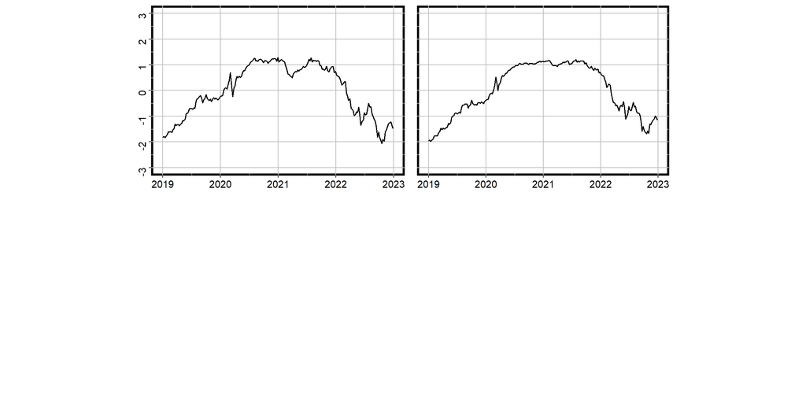

Standardized adjusted closing prices for Vanguard Bond Index Funds

```r
bond_plots_lst <- purrr::map(
  1:2,
  build_plot,
  dt = bond_dt,
  symbols = bond_symbols_v,
  show_x = c(1, 2),
  show_y = 1
)

layout <- list(
  plots = bond_plots_lst,
  rows = c(1, 1),
  cols = c(1, 2)
)

RplotterPkg::multi_panel_grid(
  layout = layout,
  row_heights = c(8, 8.5),
  col_widths = c(10.5,10)
)
```

## 1.5 Sector-Foreign Plots

```r
sector_symbols_v <- c(
  VGSLX = "Real Estate Index Fund-RN",
  VGHCX = "Health Care Fund Inv",
  VFWAX = "FTSE All World ex-US Adm"
)
sector_dt <- fund_prices_dt[Symbol %in% names(sector_symbols_v),]
```

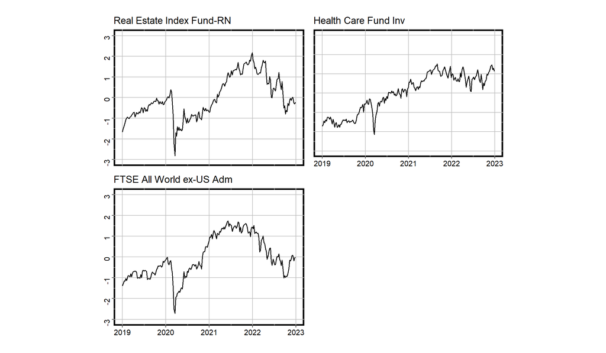

Standardized adjusted closing prices for Vanguard Sector/Foreign Index Funds

```r
sector_plots_lst <- purrr::map(
  1:3,
  build_plot,
  dt = sector_dt,
  symbols = sector_symbols_v,
  show_x = c(2, 3),
  show_y = c(1, 3)
)

layout <- list(
  plots = sector_plots_lst,
  rows = c(1, 1, 2),
  cols = c(1, 2, 1)
)

RplotterPkg::multi_panel_grid(
  layout = layout,
  row_heights = c(8, 8.5),
  col_widths = c(10.5,10)
)
```